# Diagrams.net - Draw.io

Kit Transue

# Diagrams.net (formerly draw.io)

Diagrams.net is a free diagramming tool that:

- has a palette for building Entity-Relationship Diagrams (ERDs)
- can run in the cloud
- can be installed on a desktop
- is flexible about where you store files (cloud; locally)
- stores its files in an XML format (with the extension .drawio)
- is free and open source

It was formerly known as “Draw.io”; hence its filenames.

## Installing/running

I install and run locally, which makes it slightly less work to work with files downloaded from Canvas.

There are very few differences between the local and online versions.

The landing page at https://www.diagrams.net offers a “start” or “download” option: just click and go.

## File storage

I store files locally. For the online version, choose “Device” as Save diagrams to:, or choose one of the other options.

## Creating a new document

I start all documents as ERDs. What this gives me:

- a basic template (which is sometimes annoying to replace)
- immediate access to the Entity-Relation Palette
- the chance to set the default line style from the template

## Palette

Work with the “Entity Relation” palette. I suggest collapsing the General and any other open palettes.

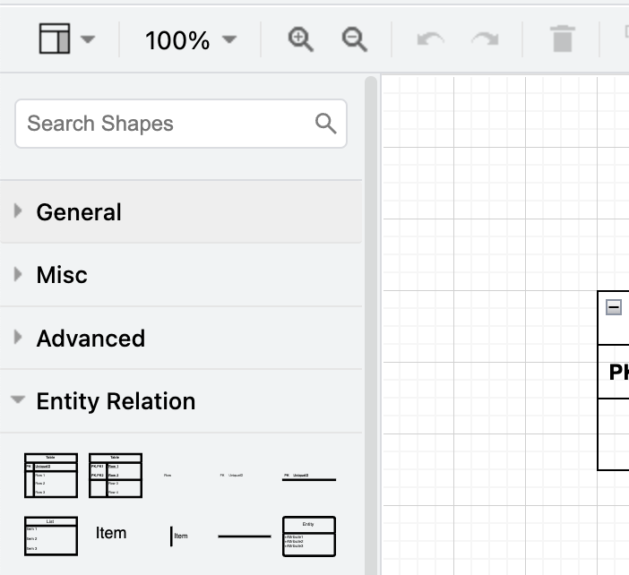

Entity Relation Palette

### Entity

“Table” is what we are calling in class an “Entity.” Use Table.

The first two tables should work pretty well: first is for basic elements; the second is for join tables or other tables with a compound key where the key references primary keys from two other tables.

#### Standard Table

A table with a simple key:

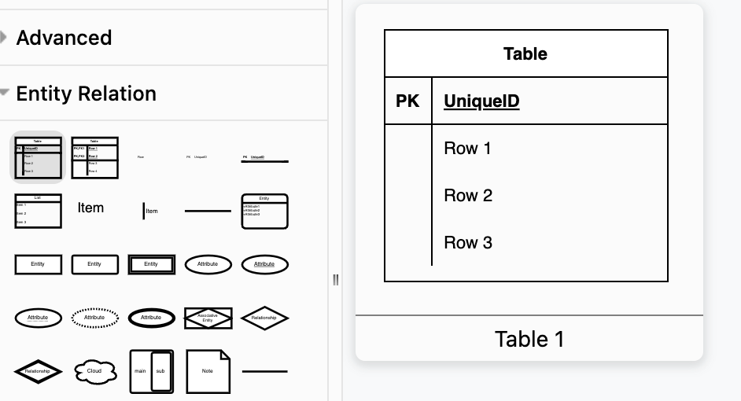

Single-key Entity

### Join Table

The second table in the Entity Relation palette come preconfigured for a join table with a composite, compound key made from two foreign keys:

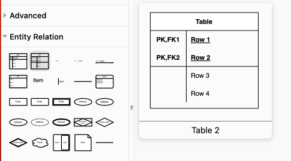

Join Entity

### Attributes

Attributes can be added in three ways:

- Control/Command Enter to create a new row of the same kind (my preferred)
- drag from palette (if attribute type isn’t already in the document)
- select attribute row from somewhere else, copy/paste it, then drag

#### Non-prime (non-key) attribute

“Table Row 1” is an attribute that is not a primary or foreign key:

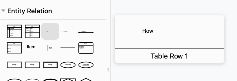

#### Foreign Key Attribute

“Table Row 2” is a foreign key attribute:

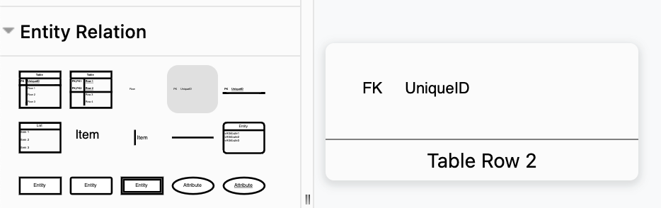

(Attribute in non-prime: it is not a part of a key.)

#### Primary Key Attribute

“Table Row 3” is a primary key:

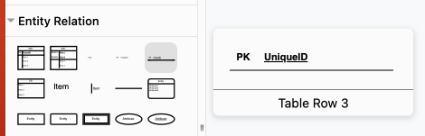

(This can be used for composite keys.)

## Relation lines

- drag from the blue arrow to make a default relation
- adjust line ends with inspector
- copy may be faster than finding in the palette (esp. since ends are hard to see)
- use the template to set the default line type (right click/two-finger tap)

My favorite line style (1/Mandatory to Many/Optional) doesn’t seem to live in the ERD Palette, but is shown in the default diagram. Make it your default.

## Tips

- use the ERD panel
- attach items together well
  - check by rearranging
- remember to set the default line style
  - stored per document
- drag to build lines without going to palette
- control (or command) return to add new attributes
- use attribute drag handles to move or rearrange

## Advanced

Sharing on Google Drive or Microsoft OneDrive allows collaboration (with shared views of cursor).

You can paste SQL CREATE statements into Arrange…Insert…Advanced…SQL.

[Tips from diagrams.net for working with ERDs](https://www.drawio.com/blog/entity-relationship-tables)